# AI Portfolio Optimization

Monet Knupp

2026-04-19

### 1ST AI Prompt

“Can you write R code using quantmod to download adjusted closing prices from Yahoo Finance for the following ETFs over the last 3 years: SPY, QQQ, IWM, VEA, VWO, AGG, TLT, LQD, VNQ, and GLD. Please make sure to organize the code clearly and include package installation commands.”

[ChatGPT](https://chatgpt.com/share/69e53ea2-e08c-83ea-bc5c-443398df8c46)

```r
############################################################
# Download Adjusted Closing Prices for ETFs from Yahoo Finance
# ETFs: SPY, QQQ, IWM, VEA, VWO, AGG, TLT, LQD, VNQ, GLD
# Period: Last 3 Years
############################################################

# -----------------------------
# Setup: Install & Load Packages
# -----------------------------

required_packages <- c("quantmod", "xts", "PerformanceAnalytics", "corrplot")

# Set CRAN mirror (THIS FIXES YOUR ERROR)
options(repos = c(CRAN = "https://cloud.r-project.org"))

# Install missing packages only
installed_packages <- rownames(installed.packages())

for (pkg in required_packages) {
  if (!(pkg %in% installed_packages)) {
    install.packages(pkg)
  }
}

# Load libraries
library(quantmod)
library(xts)
library(PerformanceAnalytics)
library(corrplot)
# -----------------------------
# 3. Define ETF tickers
# -----------------------------
etf_symbols <- c("SPY", "QQQ", "IWM", "VEA", "VWO",
                 "AGG", "TLT", "LQD", "VNQ", "GLD")

# -----------------------------
# 4. Define date range
# -----------------------------
end_date <- Sys.Date()
start_date <- end_date - 365 * 3

# -----------------------------
# 5. Download price data
# -----------------------------
getSymbols(Symbols = etf_symbols,
           src = "yahoo",
           from = start_date,
           to = end_date,
           auto.assign = TRUE)
```

```
##  [1] "SPY" "QQQ" "IWM" "VEA" "VWO" "AGG" "TLT" "LQD" "VNQ" "GLD"
```

```r
# -----------------------------
# 6. Extract Adjusted Close prices
# -----------------------------
adjusted_prices_list <- lapply(etf_symbols, function(symbol) {
  Ad(get(symbol))
})

# Rename each column to just the ticker symbol
for (i in seq_along(adjusted_prices_list)) {
  colnames(adjusted_prices_list[[i]]) <- etf_symbols[i]
}

# Merge all adjusted close series into one object
adjusted_prices <- do.call(merge, adjusted_prices_list)

# -----------------------------
# 7. View results
# -----------------------------
head(adjusted_prices)
```

```
##                 SPY      QQQ      IWM      VEA      VWO      AGG      TLT
## 2023-04-20 396.3546 310.7676 171.1003 41.95312 36.67588 88.94836 92.97663
## 2023-04-21 396.6625 311.0918 171.3222 42.08919 36.33031 88.79612 92.45415
## 2023-04-24 397.0763 310.4434 171.2064 42.17083 36.28484 89.14532 93.34856
## 2023-04-25 390.7732 304.5872 166.9803 41.50864 35.66645 89.70052 94.72121
## 2023-04-26 389.1181 306.4344 165.3689 41.51772 35.91198 89.36921 93.71165
## 2023-04-27 396.8646 314.7667 167.5785 42.04383 36.37578 89.04684 92.78176
##                 LQD      VNQ    GLD
## 2023-04-20 95.48081 72.95435 186.09
## 2023-04-21 95.54216 72.96319 184.25
## 2023-04-24 95.96291 72.68859 184.81
## 2023-04-25 96.38362 71.97111 185.75
## 2023-04-26 95.96291 71.28018 184.74
## 2023-04-27 95.61225 72.89233 184.75
```

```r
tail(adjusted_prices)
```

```
##               SPY    QQQ    IWM   VEA   VWO   AGG   TLT    LQD   VNQ    GLD
## 2026-04-10 679.46 611.07 261.30 67.74 56.75 99.32 86.49 109.20 92.98 437.13
## 2026-04-13 686.10 617.39 265.07 68.21 57.18 99.52 86.75 109.62 93.33 435.36
## 2026-04-14 694.46 628.60 268.72 68.89 57.98 99.78 87.21 109.98 94.22 445.09
## 2026-04-15 699.94 637.40 269.39 68.70 58.09 99.62 86.83 109.94 94.29 440.46
## 2026-04-16 701.66 640.47 269.95 68.63 58.21 99.48 86.28 109.43 95.16 440.08
## 2026-04-17 710.14 648.85 275.78 69.63 59.18 99.85 87.07 110.04 96.68 445.93
```

```r
# Optional: check structure
str(adjusted_prices)
```

```
## An xts object on 2023-04-20 / 2026-04-17 containing:
##   Data:    double [751, 10]
##   Columns: SPY, QQQ, IWM, VEA, VWO ... with 5 more columns
##   Index:   Date [751] (TZ: "UTC")
##   xts Attributes:
##     $ src    : chr "yahoo"
##     $ updated: POSIXct[1:1], format: "2026-04-19 17:38:55"
```

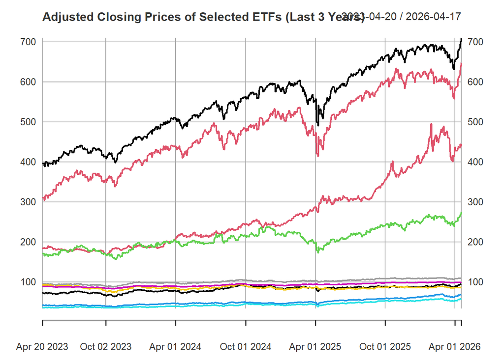

```r
# -----------------------------
# 8. Optional - Save to CSV
# -----------------------------
adjusted_prices_df <- data.frame(Date = index(adjusted_prices),
                                 coredata(adjusted_prices))

write.csv(adjusted_prices_df,
          file = "etf_adjusted_prices_last_3_years.csv",
          row.names = FALSE)

# -----------------------------
# 9. Optional - Plot prices
# -----------------------------
plot(adjusted_prices,
     main = "Adjusted Closing Prices of Selected ETFs (Last 3 Years)",
     cex.main = 1.2,     # controls title size (smaller = cleaner)
     adj = 0.5)          # centers the title
```

**A slightly cleaner version for just the main task is this:**

```r
# Install packages if needed
pkgs <- c("quantmod", "xts")
new_pkgs <- pkgs[!(pkgs %in% rownames(installed.packages()))]
if (length(new_pkgs) > 0) install.packages(new_pkgs)

# Load libraries
library(quantmod)
library(xts)

# ETF symbols
symbols <- c("SPY", "QQQ", "IWM", "VEA", "VWO",
             "AGG", "TLT", "LQD", "VNQ", "GLD")

# Date range: last 3 years
start_date <- Sys.Date() - 365 * 3
end_date <- Sys.Date()

# Download data
getSymbols(symbols, src = "yahoo", from = start_date, to = end_date)
```

```
##  [1] "SPY" "QQQ" "IWM" "VEA" "VWO" "AGG" "TLT" "LQD" "VNQ" "GLD"
```

```r
# Extract adjusted close prices
prices <- do.call(merge, lapply(symbols, function(sym) Ad(get(sym))))
colnames(prices) <- symbols

# Preview
head(prices)
```

```
##                 SPY      QQQ      IWM      VEA      VWO      AGG      TLT
## 2023-04-20 396.3546 310.7676 171.1002 41.95313 36.67588 88.94838 92.97662
## 2023-04-21 396.6625 311.0918 171.3222 42.08918 36.33031 88.79614 92.45412
## 2023-04-24 397.0763 310.4433 171.2064 42.17083 36.28484 89.14535 93.34857
## 2023-04-25 390.7732 304.5871 166.9803 41.50864 35.66645 89.70049 94.72118
## 2023-04-26 389.1180 306.4345 165.3690 41.51772 35.91198 89.36919 93.71164
## 2023-04-27 396.8646 314.7667 167.5785 42.04383 36.37578 89.04687 92.78179
##                 LQD      VNQ    GLD
## 2023-04-20 95.48080 72.95435 186.09
## 2023-04-21 95.54214 72.96320 184.25
## 2023-04-24 95.96291 72.68860 184.81
## 2023-04-25 96.38366 71.97110 185.75
## 2023-04-26 95.96291 71.28017 184.74
## 2023-04-27 95.61231 72.89235 184.75
```

```r
tail(prices)
```

```
##               SPY    QQQ    IWM   VEA   VWO   AGG   TLT    LQD   VNQ    GLD
## 2026-04-10 679.46 611.07 261.30 67.74 56.75 99.32 86.49 109.20 92.98 437.13
## 2026-04-13 686.10 617.39 265.07 68.21 57.18 99.52 86.75 109.62 93.33 435.36
## 2026-04-14 694.46 628.60 268.72 68.89 57.98 99.78 87.21 109.98 94.22 445.09
## 2026-04-15 699.94 637.40 269.39 68.70 58.09 99.62 86.83 109.94 94.29 440.46
## 2026-04-16 701.66 640.47 269.95 68.63 58.21 99.48 86.28 109.43 95.16 440.08
## 2026-04-17 710.14 648.85 275.78 69.63 59.18 99.85 87.07 110.04 96.68 445.93
```

### 2ND. AI Prompt

great! using the downloaded ETF price data for SPY, QQQ, IWM, VEA, VWO, AGG, TLT, LQD, VNQ, and GLD, write R code to calculate daily log returns, annualized returns, annualized volatility, and a correlation matrix. Also include a correlation heatmap and a cumulative returns chart.

Also, added few more prompt to fix the library issues and chart alignment, which will be seen at the end of the convo with chatgpt.

[ChatGPT](https://chatgpt.com/share/69e53ea2-e08c-83ea-bc5c-443398df8c46)

```r
############################################################
# ETF Return Analysis and Visualization
# Assets: SPY, QQQ, IWM, VEA, VWO, AGG, TLT, LQD, VNQ, GLD
# Measures:
#  - Daily log returns
#  - Annualized returns
#  - Annualized volatility
#  - Correlation matrix
#  - Correlation heatmap
#  - Cumulative returns chart
############################################################

# ----------------------------------------------------------
# 1. Install required packages
# ----------------------------------------------------------
required_packages <- c("quantmod", "xts", "PerformanceAnalytics", "corrplot")

installed_packages <- rownames(installed.packages())

for (pkg in required_packages) {
  if (!(pkg %in% installed_packages)) {
    install.packages(pkg)
  }
}

# ----------------------------------------------------------
# 2. Load libraries
# ----------------------------------------------------------
library(quantmod)
library(xts)
library(PerformanceAnalytics)
library(corrplot)

# ----------------------------------------------------------
# 3. Define ETF tickers
# ----------------------------------------------------------
etf_symbols <- c("SPY", "QQQ", "IWM", "VEA", "VWO",
                 "AGG", "TLT", "LQD", "VNQ", "GLD")

# ----------------------------------------------------------
# 4. Set date range (last 3 years)
# ----------------------------------------------------------
end_date <- Sys.Date()
start_date <- end_date - 365 * 3

# ----------------------------------------------------------
# 5. Download ETF price data from Yahoo Finance
# ----------------------------------------------------------
getSymbols(Symbols = etf_symbols,
           src = "yahoo",
           from = start_date,
           to = end_date,
           auto.assign = TRUE)
```

```
##  [1] "SPY" "QQQ" "IWM" "VEA" "VWO" "AGG" "TLT" "LQD" "VNQ" "GLD"
```

```r
# ----------------------------------------------------------
# 6. Extract Adjusted Closing Prices
# ----------------------------------------------------------
adjusted_prices_list <- lapply(etf_symbols, function(symbol) {
  Ad(get(symbol))
})

# Rename each column with ticker symbol
for (i in seq_along(adjusted_prices_list)) {
  colnames(adjusted_prices_list[[i]]) <- etf_symbols[i]
}

# Merge into one xts object
adjusted_prices <- do.call(merge, adjusted_prices_list)

# Preview price data
head(adjusted_prices)
```

```
##                 SPY      QQQ      IWM      VEA      VWO      AGG      TLT
## 2023-04-20 396.3546 310.7676 171.1002 41.95311 36.67587 88.94837 92.97664
## 2023-04-21 396.6625 311.0919 171.3222 42.08919 36.33030 88.79613 92.45415
## 2023-04-24 397.0763 310.4433 171.2064 42.17083 36.28484 89.14536 93.34857
## 2023-04-25 390.7732 304.5872 166.9803 41.50864 35.66645 89.70052 94.72118
## 2023-04-26 389.1180 306.4344 165.3690 41.51772 35.91198 89.36920 93.71166
## 2023-04-27 396.8646 314.7666 167.5785 42.04383 36.37577 89.04685 92.78181
##                 LQD      VNQ    GLD
## 2023-04-20 95.48080 72.95435 186.09
## 2023-04-21 95.54216 72.96319 184.25
## 2023-04-24 95.96290 72.68859 184.81
## 2023-04-25 96.38364 71.97111 185.75
## 2023-04-26 95.96290 71.28017 184.74
## 2023-04-27 95.61228 72.89234 184.75
```

```r
tail(adjusted_prices)
```

```
##               SPY    QQQ    IWM   VEA   VWO   AGG   TLT    LQD   VNQ    GLD
## 2026-04-10 679.46 611.07 261.30 67.74 56.75 99.32 86.49 109.20 92.98 437.13
## 2026-04-13 686.10 617.39 265.07 68.21 57.18 99.52 86.75 109.62 93.33 435.36
## 2026-04-14 694.46 628.60 268.72 68.89 57.98 99.78 87.21 109.98 94.22 445.09
## 2026-04-15 699.94 637.40 269.39 68.70 58.09 99.62 86.83 109.94 94.29 440.46
## 2026-04-16 701.66 640.47 269.95 68.63 58.21 99.48 86.28 109.43 95.16 440.08
## 2026-04-17 710.14 648.85 275.78 69.63 59.18 99.85 87.07 110.04 96.68 445.93
```

```r
# ----------------------------------------------------------
# 7. Calculate Daily Log Returns
# ----------------------------------------------------------
log_returns <- na.omit(Return.calculate(adjusted_prices, method = "log"))

# Preview return data
head(log_returns)
```

```
##                      SPY          QQQ           IWM           VEA          VWO
## 2023-04-21  0.0007765075  0.001042838  0.0012961994  0.0032383215 -0.009466930
## 2023-04-24  0.0010426298 -0.002086863 -0.0006757855  0.0019376817 -0.001252179
## 2023-04-25 -0.0160010368 -0.019043788 -0.0249943042 -0.0158269568 -0.017189528
## 2023-04-26 -0.0042446542  0.006046180 -0.0096964880  0.0002187011  0.006860450
## 2023-04-27  0.0197124008  0.026827753  0.0132726698  0.0125922680  0.012831974
## 2023-04-28  0.0084988547  0.006875102  0.0087136367  0.0002158268  0.005982370
##                     AGG          TLT           LQD           VNQ           GLD
## 2023-04-21 -0.001712987 -0.005635449  0.0006424696  0.0001211982 -9.936877e-03
## 2023-04-24  0.003925119  0.009627753  0.0043940239 -0.0037706027  3.034726e-03
## 2023-04-25  0.006208362  0.014597098  0.0043748008 -0.0099196862  5.073427e-03
## 2023-04-26 -0.003700481 -0.010715023 -0.0043748008 -0.0096465257 -5.452223e-03
## 2023-04-27 -0.003613463 -0.009971989 -0.0036603577  0.0223653524  5.409893e-05
## 2023-04-28  0.005115263  0.016001576  0.0077623480  0.0121988121  2.706159e-04
```

```r
tail(log_returns)
```

```
##                      SPY         QQQ          IWM          VEA         VWO
## 2026-04-10 -0.0006619996 0.001441143 -0.002522662  0.002808706 0.005477554
## 2026-04-13  0.0097249567 0.010289408  0.014324844  0.006914352 0.007548536
## 2026-04-14  0.0121112427 0.017994147  0.013675980  0.009919853 0.013893923
## 2026-04-15  0.0078600238 0.013902355  0.002490248 -0.002761866 0.001895419
## 2026-04-16  0.0024542974 0.004804796  0.002076604 -0.001019438 0.002063611
## 2026-04-17  0.0120132364 0.012999291  0.021366640  0.014465753 0.016526507
##                     AGG          TLT          LQD         VNQ           GLD
## 2026-04-10 -0.001710158 -0.002425073 -0.002652166 0.002153366 -0.0017827733
## 2026-04-13  0.002011638  0.003001643  0.003838829 0.003757167 -0.0040574035
## 2026-04-14  0.002609155  0.005288574  0.003278697 0.009490867  0.0221032593
## 2026-04-15 -0.001604775 -0.004366788 -0.000363777 0.000742663 -0.0104568847
## 2026-04-16 -0.001406323 -0.006354398 -0.004649706 0.009184575 -0.0008631179
## 2026-04-17  0.003712392  0.009114582  0.005558866 0.015846835  0.0132054745
```

```r
# ----------------------------------------------------------
# 8. Calculate Annualized Return and Volatility
# ----------------------------------------------------------
annualized_returns <- apply(log_returns, 2, Return.annualized, scale = 252)
annualized_volatility <- apply(log_returns, 2, StdDev.annualized, scale = 252)

# Combine into one summary table
summary_stats <- data.frame(
  ETF = colnames(log_returns),
  Annualized_Return = as.numeric(annualized_returns),
  Annualized_Volatility = as.numeric(annualized_volatility)
)

print(summary_stats)
```

```
##    ETF Annualized_Return Annualized_Volatility
## 1  SPY        0.20251819            0.15175406
## 2  QQQ        0.25610029            0.19656801
## 3  IWM        0.14795905            0.21183716
## 4  VEA        0.17231464            0.14980623
## 5  VWO        0.15947738            0.15982140
## 6  AGG        0.03800304            0.05561496
## 7  TLT       -0.03173421            0.14279453
## 8  LQD        0.04586975            0.07529579
## 9  VNQ        0.08354107            0.16956120
## 10 GLD        0.31486495            0.19799254
```

```r
# Optional: format as percentages
summary_stats$Annualized_Return <- round(summary_stats$Annualized_Return * 100, 2)
summary_stats$Annualized_Volatility <- round(summary_stats$Annualized_Volatility * 100, 2)

print(summary_stats)
```

```
##    ETF Annualized_Return Annualized_Volatility
## 1  SPY             20.25                 15.18
## 2  QQQ             25.61                 19.66
## 3  IWM             14.80                 21.18
## 4  VEA             17.23                 14.98
## 5  VWO             15.95                 15.98
## 6  AGG              3.80                  5.56
## 7  TLT             -3.17                 14.28
## 8  LQD              4.59                  7.53
## 9  VNQ              8.35                 16.96
## 10 GLD             31.49                 19.80
```

```r
# ----------------------------------------------------------
# 9. Correlation Matrix
# ----------------------------------------------------------
correlation_matrix <- cor(log_returns, use = "complete.obs")

print(correlation_matrix)
```

```
##           SPY        QQQ       IWM       VEA       VWO       AGG        TLT
## SPY 1.0000000 0.95234377 0.8059755 0.7724035 0.6773164 0.1635345 0.12352198
## QQQ 0.9523438 1.00000000 0.7050635 0.7024824 0.6547470 0.1221549 0.08220282
## IWM 0.8059755 0.70506350 1.0000000 0.7315741 0.6208286 0.2263999 0.16844249
## VEA 0.7724035 0.70248238 0.7315741 1.0000000 0.8239491 0.3106005 0.23006409
## VWO 0.6773164 0.65474698 0.6208286 0.8239491 1.0000000 0.2163942 0.13671185
## AGG 0.1635345 0.12215494 0.2263999 0.3106005 0.2163942 1.0000000 0.93600885
## TLT 0.1235220 0.08220282 0.1684425 0.2300641 0.1367119 0.9360089 1.00000000
## LQD 0.3269294 0.27248220 0.3612389 0.4244119 0.3167619 0.9526198 0.91865028
## VNQ 0.5732238 0.41392164 0.6753597 0.6125678 0.4696570 0.4468284 0.40109864
## GLD 0.1174818 0.11367872 0.1561498 0.3453660 0.3399889 0.2141733 0.14353387
##           LQD       VNQ       GLD
## SPY 0.3269294 0.5732238 0.1174818
## QQQ 0.2724822 0.4139216 0.1136787
## IWM 0.3612389 0.6753597 0.1561498
## VEA 0.4244119 0.6125678 0.3453660
## VWO 0.3167619 0.4696570 0.3399889
## AGG 0.9526198 0.4468284 0.2141733
## TLT 0.9186503 0.4010986 0.1435339
## LQD 1.0000000 0.5244152 0.2038225
## VNQ 0.5244152 1.0000000 0.1603461
## GLD 0.2038225 0.1603461 1.0000000
```

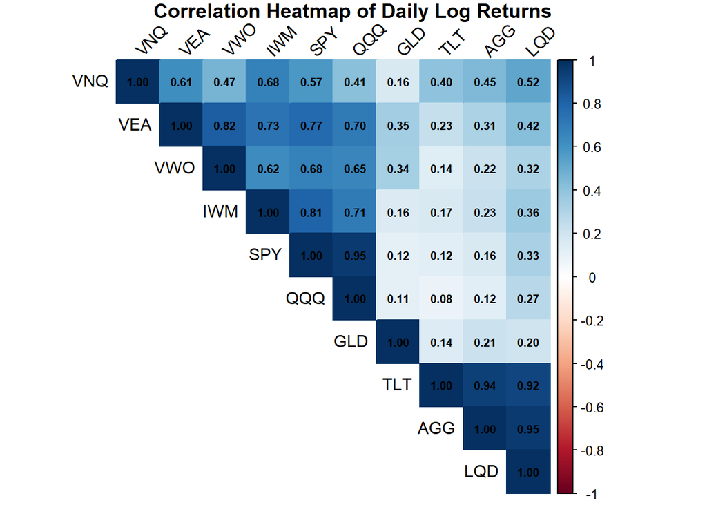

```r
# ----------------------------------------------------------
# 10. Correlation Heatmap
# ----------------------------------------------------------
corrplot(correlation_matrix,
         method = "color",
         type = "upper",
         order = "hclust",
         addCoef.col = "black",
         tl.col = "black",
         tl.srt = 45,
         number.cex = 0.7,
         mar = c(0, 0, 1, 0),
         title = "Correlation Heatmap of Daily Log Returns")
```

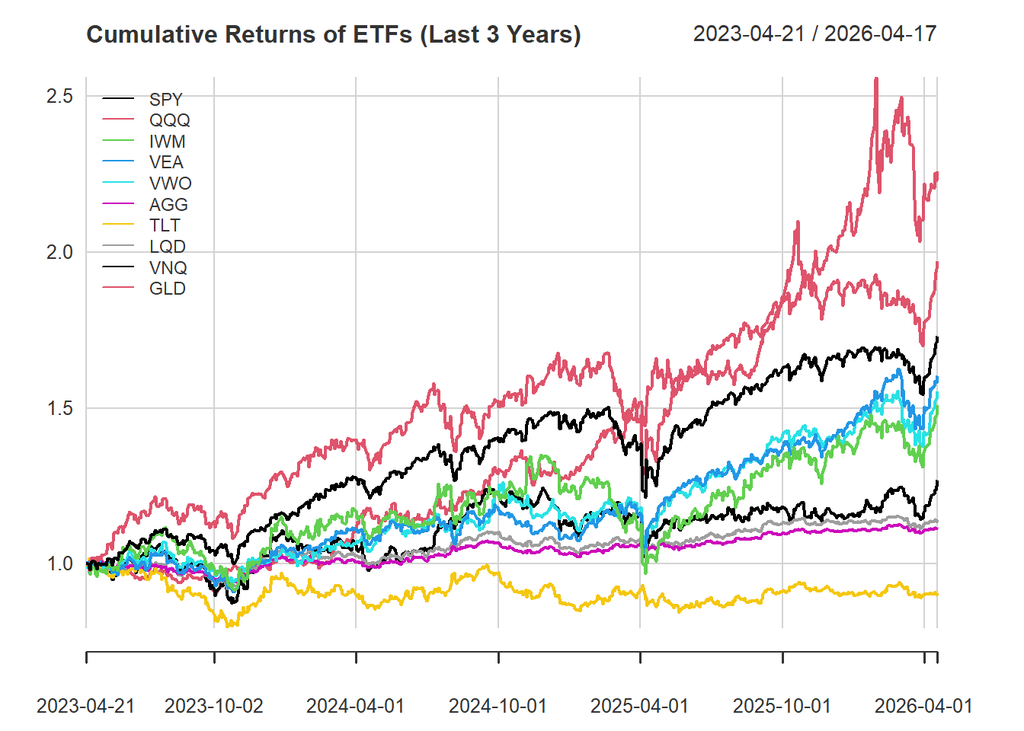

```r
# ----------------------------------------------------------
# 11. Cumulative Returns Chart
# ----------------------------------------------------------
chart.CumReturns(log_returns,
                 wealth.index = TRUE,
                 legend.loc = "topleft",
                 main = "Cumulative Returns of ETFs (Last 3 Years)")
```

```r
# ----------------------------------------------------------
# 12. Optional: Save outputs
# ----------------------------------------------------------
write.csv(summary_stats,
          file = "etf_summary_statistics.csv",
          row.names = FALSE)

write.csv(correlation_matrix,
          file = "etf_correlation_matrix.csv",
          row.names = TRUE)
```

### 3RD AI Prompt

I want you to Write R code for a mean-variance optimized portfolio using PortfolioAnalytics and I want it to align to the results of my initial prompt “https://chatgpt.com/share/69e53ea2-e08c-83ea-bc5c-443398df8c46”

[ChatGPT](https://chatgpt.com/share/69e54444-163c-83ea-9d5c-27a794c7aeac)

```r
############################################################
# Mean-Variance Optimized Portfolio using PortfolioAnalytics
# ETFs: SPY, QQQ, IWM, VEA, VWO, AGG, TLT, LQD, VNQ, GLD
# Data Source: Yahoo Finance
# Horizon: Last 3 Years
############################################################

# =========================
# 1. Install and load packages
# =========================
required_packages <- c(
  "quantmod",
  "PerformanceAnalytics",
  "PortfolioAnalytics",
  "ROI",
  "ROI.plugin.quadprog",
  "ROI.plugin.glpk",
  "xts",
  "zoo",
  "ggplot2",
  "reshape2",
  "scales"
)

installed_packages <- rownames(installed.packages())

for (pkg in required_packages) {
  if (!(pkg %in% installed_packages)) {
    install.packages(pkg, dependencies = TRUE)
  }
}

library(quantmod)
library(PerformanceAnalytics)
library(PortfolioAnalytics)
library(ROI)
library(ROI.plugin.quadprog)
library(ROI.plugin.glpk)
library(xts)
library(zoo)
library(ggplot2)
library(reshape2)
library(scales)
# =========================
# 2. Define ETF universe and download data
# =========================
etfs <- c("SPY", "QQQ", "IWM", "VEA", "VWO", "AGG", "TLT", "LQD", "VNQ", "GLD")

start_date <- Sys.Date() - 365 * 3
end_date   <- Sys.Date()

getSymbols(Symbols = etfs,
           src = "yahoo",
           from = start_date,
           to = end_date,
           auto.assign = TRUE,
           warnings = FALSE)
```

```
##  [1] "SPY" "QQQ" "IWM" "VEA" "VWO" "AGG" "TLT" "LQD" "VNQ" "GLD"
```

```r
# =========================
# 3. Extract Adjusted Close prices and merge
# =========================
price_list <- lapply(etfs, function(ticker) Ad(get(ticker)))
prices <- do.call(merge, price_list)
colnames(prices) <- etfs

# Remove rows with all missing values, then carry forward/backward if needed
prices <- prices[!apply(is.na(prices), 1, all), ]
prices <- na.locf(prices, na.rm = FALSE)
prices <- na.locf(prices, fromLast = TRUE)

# =========================
# 4. Compute daily log returns
# =========================
returns <- na.omit(Return.calculate(prices, method = "log"))
colnames(returns) <- etfs

# =========================
# 5. Summary statistics
# =========================
annualized_returns <- Return.annualized(returns, geometric = TRUE)
annualized_vol     <- StdDev.annualized(returns)
cor_matrix         <- cor(returns, use = "complete.obs")

cat("Annualized Returns:\n")
```

```
## Annualized Returns:
```

```r
print(round(annualized_returns, 4))
```

```
##                      SPY    QQQ   IWM    VEA    VWO   AGG     TLT    LQD    VNQ
## Annualized Return 0.2025 0.2561 0.148 0.1723 0.1595 0.038 -0.0317 0.0459 0.0835
##                      GLD
## Annualized Return 0.3149
```

```r
cat("\nAnnualized Volatility:\n")
```

```
##
## Annualized Volatility:
```

```r
print(round(annualized_vol, 4))
```

```
##                                  SPY    QQQ    IWM    VEA    VWO    AGG    TLT
## Annualized Standard Deviation 0.1518 0.1966 0.2118 0.1498 0.1598 0.0556 0.1428
##                                  LQD    VNQ   GLD
## Annualized Standard Deviation 0.0753 0.1696 0.198
```

```r
cat("\nCorrelation Matrix:\n")
```

```
##
## Correlation Matrix:
```

```r
print(round(cor_matrix, 3))
```

```
##       SPY   QQQ   IWM   VEA   VWO   AGG   TLT   LQD   VNQ   GLD
## SPY 1.000 0.952 0.806 0.772 0.677 0.164 0.124 0.327 0.573 0.117
## QQQ 0.952 1.000 0.705 0.702 0.655 0.122 0.082 0.272 0.414 0.114
## IWM 0.806 0.705 1.000 0.732 0.621 0.226 0.168 0.361 0.675 0.156
## VEA 0.772 0.702 0.732 1.000 0.824 0.311 0.230 0.424 0.613 0.345
## VWO 0.677 0.655 0.621 0.824 1.000 0.216 0.137 0.317 0.470 0.340
## AGG 0.164 0.122 0.226 0.311 0.216 1.000 0.936 0.953 0.447 0.214
## TLT 0.124 0.082 0.168 0.230 0.137 0.936 1.000 0.919 0.401 0.144
## LQD 0.327 0.272 0.361 0.424 0.317 0.953 0.919 1.000 0.524 0.204
## VNQ 0.573 0.414 0.675 0.613 0.470 0.447 0.401 0.524 1.000 0.160
## GLD 0.117 0.114 0.156 0.345 0.340 0.214 0.144 0.204 0.160 1.000
```

```r
# =========================
# 6. Build Mean-Variance Portfolio Specification
# =========================
portfolio_spec <- portfolio.spec(assets = colnames(returns))

# Full investment constraint
portfolio_spec <- add.constraint(
  portfolio = portfolio_spec,
  type = "full_investment"
)

# Long-only constraint
portfolio_spec <- add.constraint(
  portfolio = portfolio_spec,
  type = "long_only"
)

# Optional box constraint to avoid overly concentrated weights
portfolio_spec <- add.constraint(
  portfolio = portfolio_spec,
  type = "box",
  min = 0,
  max = 0.35
)

# Mean objective: maximize expected return
portfolio_spec <- add.objective(
  portfolio = portfolio_spec,
  type = "return",
  name = "mean"
)

# Risk objective: minimize portfolio variance
portfolio_spec <- add.objective(
  portfolio = portfolio_spec,
  type = "risk",
  name = "var"
)

# =========================
# 7. Optimize the portfolio
# =========================
opt_mv <- optimize.portfolio(
  R = returns,
  portfolio = portfolio_spec,
  optimize_method = "ROI",
  trace = TRUE
)

# Extract optimal weights
mv_weights <- extractWeights(opt_mv)

cat("\nMean-Variance Optimal Weights:\n")
```

```
##
## Mean-Variance Optimal Weights:
```

```r
print(round(mv_weights, 4))
```

```
##  SPY  QQQ  IWM  VEA  VWO  AGG  TLT  LQD  VNQ  GLD
## 0.30 0.35 0.00 0.00 0.00 0.00 0.00 0.00 0.00 0.35
```

```r
# =========================
# 8. Portfolio returns
# =========================
mv_portfolio_returns <- Return.portfolio(
  R = returns,
  weights = mv_weights,
  rebalance_on = "months"
)

colnames(mv_portfolio_returns) <- "MeanVariance_Portfolio"

# =========================
# 9. Compare against Equal Weight portfolio
# =========================
equal_weights <- rep(1 / length(etfs), length(etfs))
names(equal_weights) <- etfs

ew_portfolio_returns <- Return.portfolio(
  R = returns,
  weights = equal_weights,
  rebalance_on = "months"
)

colnames(ew_portfolio_returns) <- "EqualWeight_Portfolio"

portfolio_compare <- na.omit(merge(mv_portfolio_returns, ew_portfolio_returns))

# =========================
# 10. Performance summary
# =========================
cat("\nPortfolio Performance Comparison:\n")
```

```
##
## Portfolio Performance Comparison:
```

```r
comparison_stats <- rbind(
  "Annualized Return" = Return.annualized(portfolio_compare, geometric = TRUE),
  "Annualized Volatility" = StdDev.annualized(portfolio_compare),
  "Sharpe Ratio" = SharpeRatio.annualized(portfolio_compare, Rf = 0, geometric = TRUE)
)

print(round(comparison_stats, 4))
```

```
##                                                   MeanVariance_Portfolio
## Annualized Return                                                 0.2668
## Annualized Standard Deviation                                     0.1394
## Annualized Geometric Sharpe Ratio (Rf=0%, p=95%):                 1.9141
##                                                   EqualWeight_Portfolio
## Annualized Return                                                0.1396
## Annualized Standard Deviation                                    0.1066
## Annualized Geometric Sharpe Ratio (Rf=0%, p=95%):                1.3098
```

```r
# =========================
# 11. Efficient Frontier
# =========================
frontier <- create.EfficientFrontier(
  R = returns,
  portfolio = portfolio_spec,
  type = "mean-StdDev",
  n.portfolios = 25
)
```

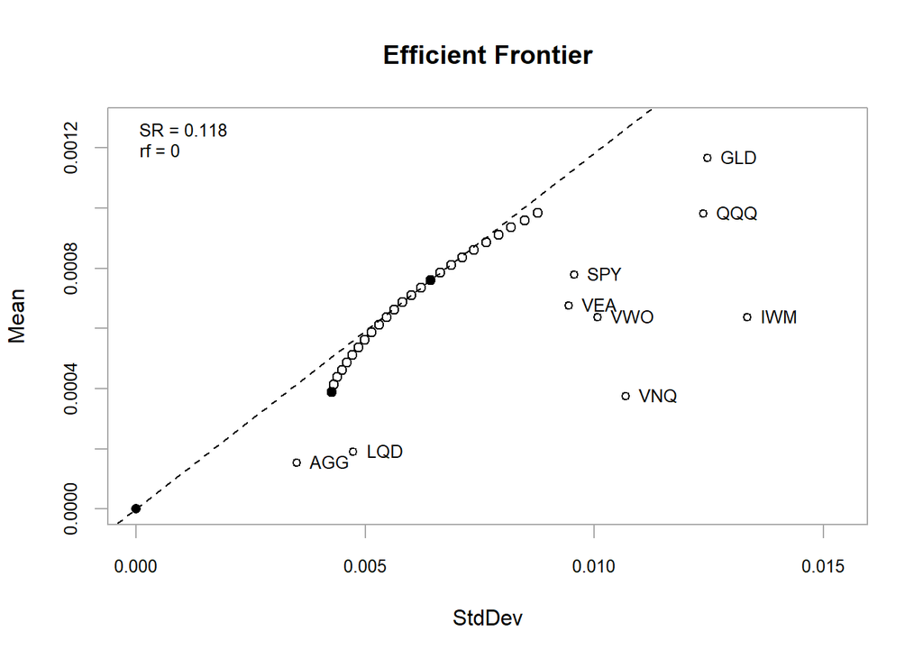

```r
chart.EfficientFrontier(frontier,
                        match.col = "StdDev",
                        n.portfolios = 25,
                        main = "Efficient Frontier")
```

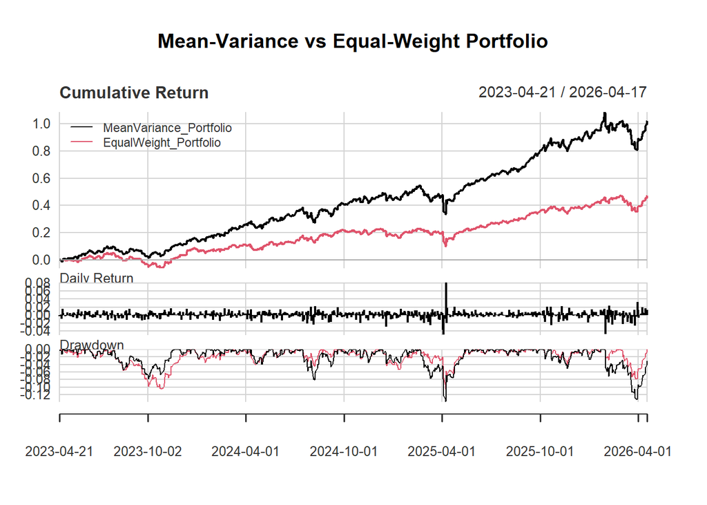

```r
# =========================
# 12. Cumulative returns chart
# =========================
charts.PerformanceSummary(
  portfolio_compare,
  main = "Mean-Variance vs Equal-Weight Portfolio"
)
```

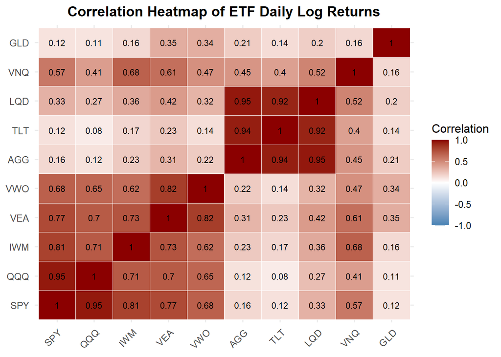

```r
# =========================
# 13. Correlation heatmap
# =========================
cor_df <- melt(cor_matrix)
colnames(cor_df) <- c("ETF1", "ETF2", "Correlation")

ggplot(cor_df, aes(x = ETF1, y = ETF2, fill = Correlation)) +
  geom_tile(color = "white") +
  geom_text(aes(label = round(Correlation, 2)), size = 3) +
  scale_fill_gradient2(low = "steelblue", mid = "white", high = "darkred",
                       midpoint = 0, limits = c(-1, 1)) +
  labs(
    title = "Correlation Heatmap of ETF Daily Log Returns",
    x = NULL,
    y = NULL
  ) +
  theme_minimal(base_size = 12) +
  theme(
    plot.title = element_text(hjust = 0.5, face = "bold"),
    axis.text.x = element_text(angle = 45, hjust = 1)
  )
```

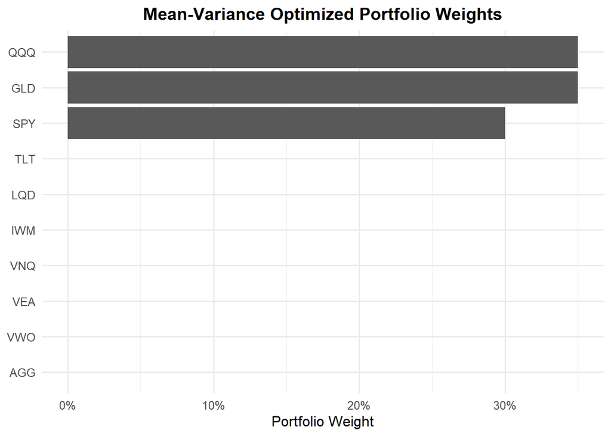

```r
# =========================
# 14. Plot portfolio weights
# =========================
weights_df <- data.frame(
  ETF = names(mv_weights),
  Weight = as.numeric(mv_weights)
)

ggplot(weights_df, aes(x = reorder(ETF, Weight), y = Weight)) +
  geom_col() +
  coord_flip() +
  scale_y_continuous(labels = percent_format(accuracy = 1)) +
  labs(
    title = "Mean-Variance Optimized Portfolio Weights",
    x = NULL,
    y = "Portfolio Weight"
  ) +
  theme_minimal(base_size = 12) +
  theme(
    plot.title = element_text(hjust = 0.5, face = "bold")
  )
```

```r
# =========================
# 15. Optional: Display top-level summary neatly
# =========================
cat("\n=============================\n")
cat("MEAN-VARIANCE PORTFOLIO SUMMARY\n")
```

```
## MEAN-VARIANCE PORTFOLIO SUMMARY
```

```r
cat("=============================\n")
cat("\nOptimal Weights:\n")
```

```
##
## Optimal Weights:
```

```r
print(round(mv_weights, 4))
```

```
##  SPY  QQQ  IWM  VEA  VWO  AGG  TLT  LQD  VNQ  GLD
## 0.30 0.35 0.00 0.00 0.00 0.00 0.00 0.00 0.00 0.35
```

```r
cat("\nAnnualized Return (MV Portfolio): ",
    round(as.numeric(Return.annualized(mv_portfolio_returns, geometric = TRUE)), 4), "\n", sep = "")
```

```
##
## Annualized Return (MV Portfolio): 0.2668
```

```r
cat("Annualized Volatility (MV Portfolio): ",
    round(as.numeric(StdDev.annualized(mv_portfolio_returns)), 4), "\n", sep = "")
```

```
## Annualized Volatility (MV Portfolio): 0.1394
```

```r
cat("Sharpe Ratio (MV Portfolio): ",
    round(as.numeric(SharpeRatio.annualized(mv_portfolio_returns, Rf = 0, geometric = TRUE)), 4), "\n", sep = "")
```

```
## Sharpe Ratio (MV Portfolio): 1.9141
```

### 4TH AI Prompt

Now, help me backtest the optimized portfolio against an equal-weight portfolio and a 60/40 benchmark

[ChatGPT](https://chatgpt.com/share/69e54735-17d8-83ea-a2b9-9c53fbf04aa9)

```r
############################################################
# STEP: Load Required Packages
############################################################

pkgs <- c(
  "quantmod",
  "PerformanceAnalytics",
  "PortfolioAnalytics",
  "ROI",
  "ROI.plugin.quadprog",
  "xts",
  "ggplot2",
  "reshape2"
)

new_pkgs <- pkgs[!(pkgs %in% installed.packages()[, "Package"])]
if (length(new_pkgs) > 0) install.packages(new_pkgs)

lapply(pkgs, library, character.only = TRUE)
```

[output not shown]

[output cut: 56 more lines]

```r
############################################################
# STEP: Define ETFs and Download Adjusted Prices
############################################################

symbols <- c("SPY", "QQQ", "IWM", "VEA", "VWO", "AGG", "TLT", "LQD", "VNQ", "GLD")

start_date <- Sys.Date() - 365 * 3
end_date   <- Sys.Date()

getSymbols(symbols, src = "yahoo", from = start_date, to = end_date, auto.assign = TRUE)
```

```
##  [1] "SPY" "QQQ" "IWM" "VEA" "VWO" "AGG" "TLT" "LQD" "VNQ" "GLD"
```

```r
############################################################
# STEP: Merge Adjusted Closing Prices
############################################################

prices <- do.call(merge, lapply(symbols, function(sym) Ad(get(sym))))
colnames(prices) <- symbols
prices <- na.omit(prices)

############################################################
# STEP: Calculate Daily Log Returns
############################################################

returns <- na.omit(Return.calculate(prices, method = "log"))

############################################################
# STEP: Mean-Variance Portfolio Optimization
############################################################

# Create portfolio specification
port_spec <- portfolio.spec(assets = colnames(returns))

# Add constraints
port_spec <- add.constraint(portfolio = port_spec, type = "full_investment")
port_spec <- add.constraint(portfolio = port_spec, type = "long_only")

# Add objectives
port_spec <- add.objective(portfolio = port_spec, type = "return", name = "mean")
port_spec <- add.objective(portfolio = port_spec, type = "risk", name = "var")

# Run optimization
opt_portfolio <- optimize.portfolio(
  R = returns,
  portfolio = port_spec,
  optimize_method = "ROI"
)

# Extract optimized weights
opt_weights <- extractWeights(opt_portfolio)

# Display optimized weights
opt_weights_df <- data.frame(
  ETF = names(opt_weights),
  Weight = round(as.numeric(opt_weights), 4)
)

print(opt_weights_df)
```

```
##    ETF Weight
## 1  SPY 0.0000
## 2  QQQ 0.1686
## 3  IWM 0.0000
## 4  VEA 0.0000
## 5  VWO 0.0000
## 6  AGG 0.0000
## 7  TLT 0.0000
## 8  LQD 0.0000
## 9  VNQ 0.0000
## 10 GLD 0.8314
```

```r
############################################################
# STEP: Construct Equal-Weight Portfolio
############################################################

n_assets <- ncol(returns)

weights_equal <- rep(1 / n_assets, n_assets)
names(weights_equal) <- colnames(returns)

ret_equal <- Return.portfolio(
  R = returns,
  weights = weights_equal,
  rebalance_on = "months"
)

############################################################
# STEP: Construct 60/40 Benchmark Portfolio
############################################################

# 60% allocated equally across equity ETFs
# 40% allocated equally across bond ETFs
# GLD is excluded from the traditional 60/40 benchmark

stock_assets <- c("SPY", "QQQ", "IWM", "VEA", "VWO", "VNQ")
bond_assets  <- c("AGG", "TLT", "LQD")

weights_6040 <- rep(0, n_assets)
names(weights_6040) <- colnames(returns)

weights_6040[stock_assets] <- 0.60 / length(stock_assets)
weights_6040[bond_assets]  <- 0.40 / length(bond_assets)

ret_6040 <- Return.portfolio(
  R = returns,
  weights = weights_6040,
  rebalance_on = "months"
)

############################################################
# STEP: Construct Mean-Variance Optimized Portfolio Returns
############################################################

ret_mvo <- Return.portfolio(
  R = returns,
  weights = opt_weights,
  rebalance_on = "months"
)

############################################################
# STEP: Merge Portfolio Returns
############################################################

portfolio_returns <- merge(ret_mvo, ret_equal, ret_6040)
colnames(portfolio_returns) <- c("Mean-Variance", "Equal Weight", "60/40")

portfolio_returns <- na.omit(portfolio_returns)

############################################################
# STEP: Performance Summary Tables
############################################################

cat("\nAnnualized Return Statistics:\n")
```

```
##
## Annualized Return Statistics:
```

```r
print(table.AnnualizedReturns(portfolio_returns))
```

```
##                           Mean-Variance Equal Weight  60/40
## Annualized Return                0.3096       0.1396 0.1094
## Annualized Std Dev               0.1721       0.1066 0.1047
## Annualized Sharpe (Rf=0%)        1.7987       1.3098 1.0449
```

```r
cat("\nRisk Metrics:\n")
```

```
##
## Risk Metrics:
```

```r
print(rbind(
  AnnualizedStdDev = StdDev.annualized(portfolio_returns),
  SharpeRatio = SharpeRatio.annualized(portfolio_returns, Rf = 0)
))
```

```
##                                         Mean-Variance Equal Weight    60/40
## Annualized Standard Deviation               0.1721142    0.1065657 0.104731
## Annualized Sharpe Ratio (Rf=0%, p=95%):     1.6545231    1.2795875 1.044004
```

```r
cat("\nMaximum Drawdown:\n")
```

```
##
## Maximum Drawdown:
```

```r
print(maxDrawdown(portfolio_returns))
```

```
##                Mean-Variance Equal Weight     60/40
## Worst Drawdown     0.1877571    0.1052311 0.1180365
```

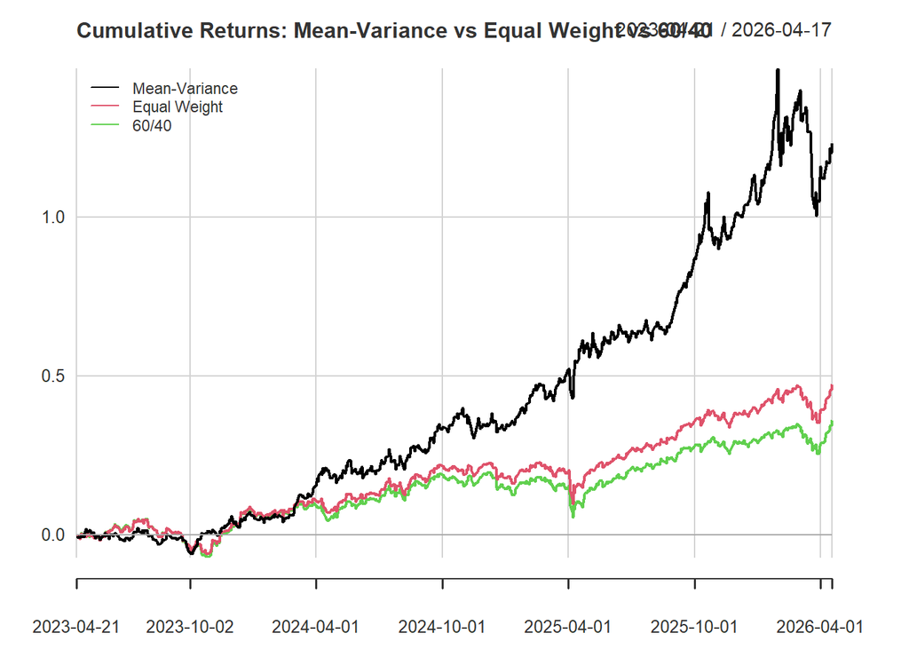

```r
############################################################
# STEP: Cumulative Returns Chart
############################################################

chart.CumReturns(
  portfolio_returns,
  legend.loc = "topleft",
  main = "Cumulative Returns: Mean-Variance vs Equal Weight vs 60/40"
)
```

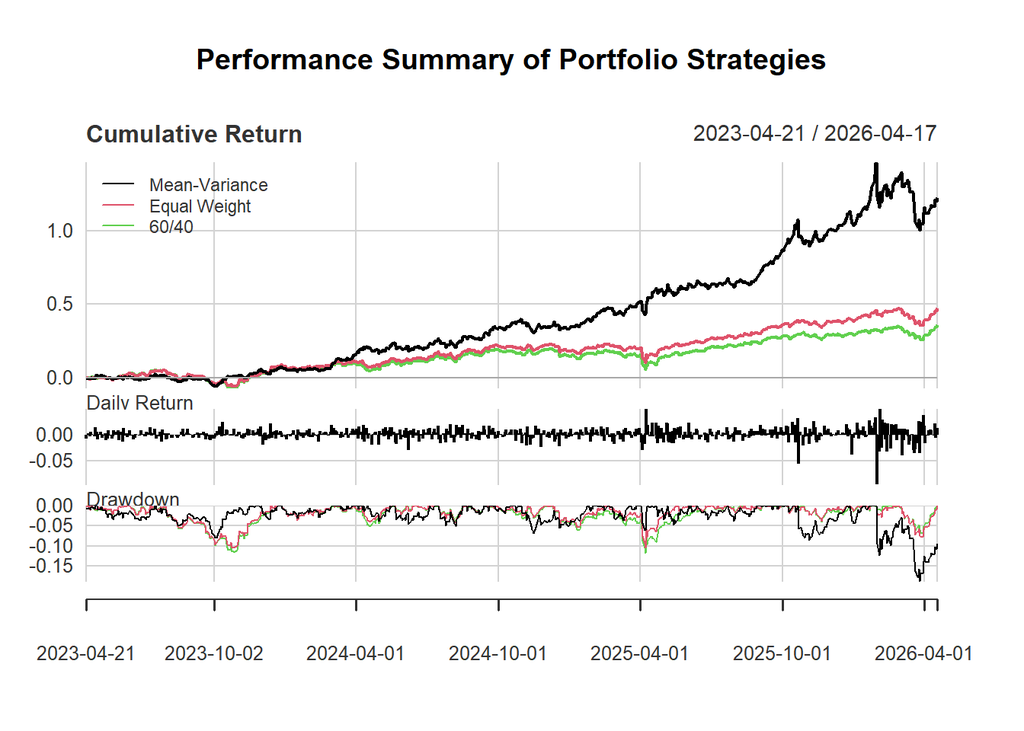

```r
############################################################
# STEP: Performance Summary Chart
############################################################

charts.PerformanceSummary(
  portfolio_returns,
  main = "Performance Summary of Portfolio Strategies"
)
```

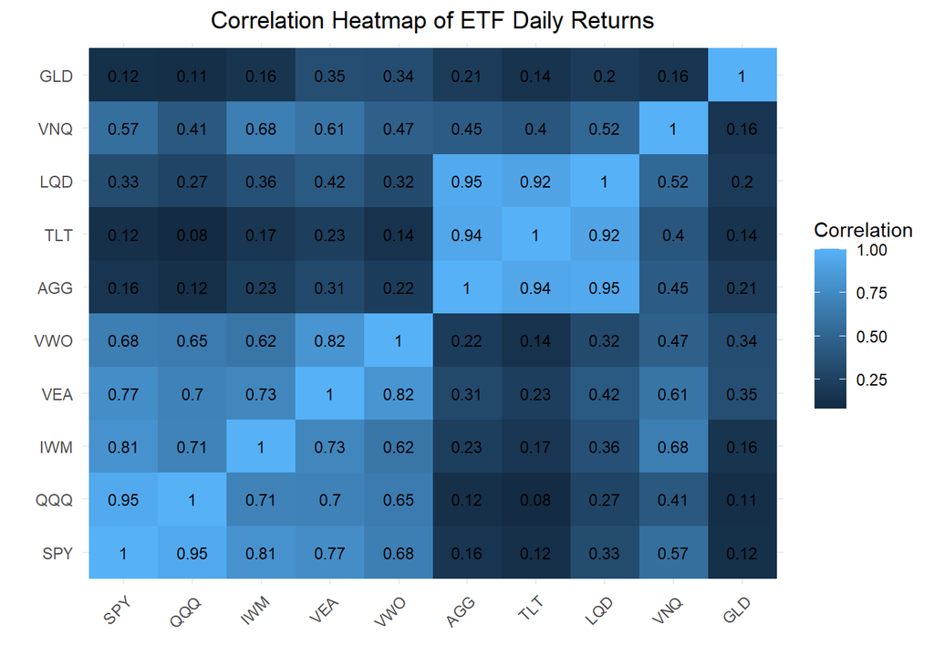

```r
############################################################
# STEP: Correlation Heatmap of ETF Returns
############################################################

cor_mat <- cor(returns)
cor_df <- melt(cor_mat)

ggplot(cor_df, aes(x = Var1, y = Var2, fill = value)) +
  geom_tile() +
  geom_text(aes(label = round(value, 2)), size = 3) +
  labs(
    title = "Correlation Heatmap of ETF Daily Returns",
    x = "",
    y = "",
    fill = "Correlation"
  ) +
  theme_minimal() +
  theme(
    plot.title = element_text(hjust = 0.5),
    axis.text.x = element_text(angle = 45, hjust = 1)
  )
```

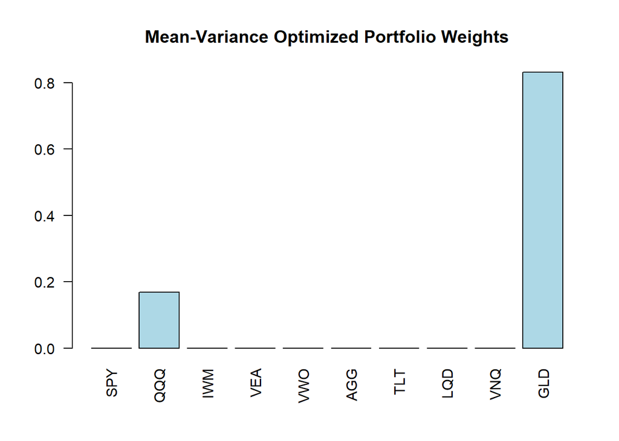

```r
############################################################
# STEP: Plot Optimized Portfolio Weights
############################################################

barplot(
  opt_weights,
  main = "Mean-Variance Optimized Portfolio Weights",
  col = "lightblue",
  las = 2
)
```

### 5TH AI Prompt

Create a cumulative returns chart and performance table using PerformanceAnalytics Make it the continuation of the discussion for the ETF setup: SPY, QQQ, IWM, VEA, VWO, AGG, TLT, LQD, VNQ, and GLD over the last 3 years, using adjusted prices from Yahoo Finance. here’s the link from our last convo 9backtesting portfolio strategies) https://chatgpt.com/share/69e54735-17d8-83ea-a2b9-9c53fbf04aa9

[ChatGPT](https://chatgpt.com/share/69e54aba-3c04-83ea-9416-b3bd9418670a)

```r
############################################################
# ETF Performance Analysis: Cumulative Returns + Performance Table
# ETFs: SPY, QQQ, IWM, VEA, VWO, AGG, TLT, LQD, VNQ, GLD
# Period: Last 3 Years
# Data Source: Yahoo Finance
############################################################

# ---------------------------
# 1. Install and load packages
# ---------------------------
pkgs <- c("quantmod", "PerformanceAnalytics", "xts")

new_pkgs <- pkgs[!(pkgs %in% installed.packages()[, "Package"])]
if (length(new_pkgs) > 0) install.packages(new_pkgs)

library(quantmod)
library(PerformanceAnalytics)
library(xts)

# ---------------------------
# 2. Define ETF tickers
# ---------------------------
tickers <- c("SPY", "QQQ", "IWM", "VEA", "VWO", "AGG", "TLT", "LQD", "VNQ", "GLD")

# ---------------------------
# 3. Download adjusted prices from Yahoo Finance
# ---------------------------
getSymbols(Symbols = tickers, src = "yahoo", from = Sys.Date() - 365*3, auto.assign = TRUE)
```

```
##  [1] "SPY" "QQQ" "IWM" "VEA" "VWO" "AGG" "TLT" "LQD" "VNQ" "GLD"
```

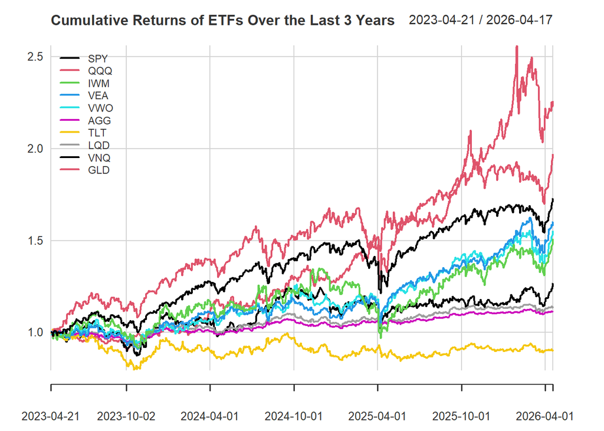

```r
# ---------------------------
# 4. Merge adjusted closing prices into one xts object
# ---------------------------
prices_list <- lapply(tickers, function(ticker) Ad(get(ticker)))
prices_xts  <- do.call(merge, prices_list)
colnames(prices_xts) <- tickers

# Remove missing rows
prices_xts <- na.omit(prices_xts)

# ---------------------------
# 5. Calculate daily log returns
# ---------------------------
returns_xts <- na.omit(Return.calculate(prices_xts, method = "log"))

# ---------------------------
# 6. Cumulative returns chart
# ---------------------------
chart.CumReturns(
  returns_xts,
  wealth.index = TRUE,
  legend.loc = "topleft",
  main = "Cumulative Returns of ETFs Over the Last 3 Years",
  ylab = "Growth of $1",
  lwd = 2
)
```

```r
# ---------------------------
# 7. Performance table using PerformanceAnalytics
# ---------------------------
# table.Stats gives a broad descriptive summary
performance_stats <- table.Stats(returns_xts)
print(round(performance_stats, 4))
```

```
##                      SPY      QQQ      IWM      VEA      VWO      AGG      TLT
## Observations    750.0000 750.0000 750.0000 750.0000 750.0000 750.0000 750.0000
## NAs               0.0000   0.0000   0.0000   0.0000   0.0000   0.0000   0.0000
## Minimum          -0.0603  -0.0641  -0.0663  -0.0654  -0.0576  -0.0127  -0.0306
## Quartile 1       -0.0033  -0.0045  -0.0077  -0.0042  -0.0047  -0.0020  -0.0057
## Median            0.0010   0.0015   0.0007   0.0009   0.0010   0.0002   0.0001
## Arithmetic Mean   0.0008   0.0010   0.0006   0.0007   0.0006   0.0002  -0.0001
## Geometric Mean    0.0007   0.0009   0.0005   0.0006   0.0006   0.0001  -0.0001
## Quartile 3        0.0059   0.0078   0.0089   0.0059   0.0063   0.0023   0.0057
## Maximum           0.0999   0.1134   0.0816   0.0720   0.0631   0.0125   0.0307
## SE Mean           0.0003   0.0005   0.0005   0.0003   0.0004   0.0001   0.0003
## LCL Mean (0.95)   0.0001   0.0001  -0.0003   0.0000  -0.0001  -0.0001  -0.0007
## UCL Mean (0.95)   0.0015   0.0019   0.0016   0.0014   0.0014   0.0004   0.0006
## Variance          0.0001   0.0002   0.0002   0.0001   0.0001   0.0000   0.0001
## Stdev             0.0096   0.0124   0.0133   0.0094   0.0101   0.0035   0.0090
## Skewness          0.6426   0.3745   0.1859   0.0258  -0.0058  -0.0626  -0.1513
## Kurtosis         18.7545  10.3884   3.1863   7.8050   4.4751   0.7380   0.5758
##                      LQD      VNQ      GLD
## Observations    750.0000 750.0000 750.0000
## NAs               0.0000   0.0000   0.0000
## Minimum          -0.0197  -0.0444  -0.1084
## Quartile 1       -0.0026  -0.0057  -0.0045
## Median            0.0002   0.0008   0.0012
## Arithmetic Mean   0.0002   0.0004   0.0012
## Geometric Mean    0.0002   0.0003   0.0011
## Quartile 3        0.0032   0.0066   0.0076
## Maximum           0.0166   0.0579   0.0616
## SE Mean           0.0002   0.0004   0.0005
## LCL Mean (0.95)  -0.0002  -0.0004   0.0003
## UCL Mean (0.95)   0.0005   0.0011   0.0021
## Variance          0.0000   0.0001   0.0002
## Stdev             0.0047   0.0107   0.0125
## Skewness         -0.1525  -0.0579  -1.1473
## Kurtosis          1.0174   2.8636  10.2337
```

```r
# ---------------------------
# 8. Cleaner summary table with key portfolio metrics
# ---------------------------
annual_return <- Return.annualized(returns_xts)
annual_vol    <- StdDev.annualized(returns_xts)
sharpe_ratio  <- SharpeRatio.annualized(returns_xts, Rf = 0)
max_drawdown  <- maxDrawdown(returns_xts)

performance_summary <- data.frame(
  ETF = rownames(annual_return),
  Annualized_Return = round(as.numeric(annual_return[, 1]), 4),
  Annualized_Volatility = round(as.numeric(annual_vol[, 1]), 4),
  Sharpe_Ratio = round(as.numeric(sharpe_ratio[, 1]), 4),
  Max_Drawdown = round(as.numeric(max_drawdown[, 1]), 4)
)

rownames(performance_summary) <- NULL

cat("\n========================================\n")
cat("Key Performance Summary Table\n")
```

```
## Key Performance Summary Table
```

```r
cat("========================================\n")
print(performance_summary)
```

```
##                 ETF Annualized_Return Annualized_Volatility Sharpe_Ratio
## 1 Annualized Return            0.2025                0.1518       1.2912
##   Max_Drawdown
## 1       0.1921
```

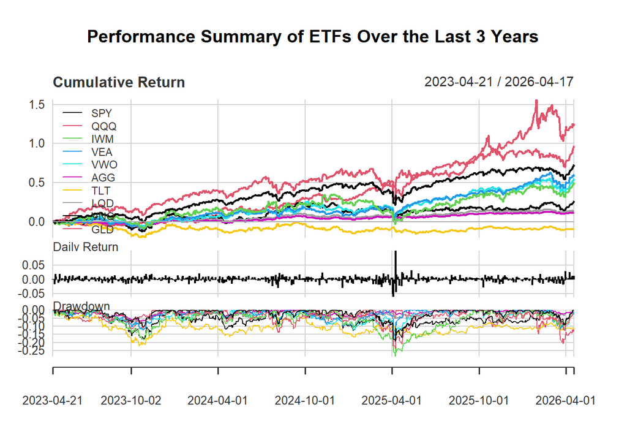

```r
# ---------------------------
# 9. Optional full performance dashboard
# ---------------------------
charts.PerformanceSummary(
  returns_xts,
  main = "Performance Summary of ETFs Over the Last 3 Years"
)
```

### 6TH AI Prompt

[ChatGPT](https://chatgpt.com/share/69e54b62-7c80-83ea-a08e-859acd03f3a2)